# Implementing Scalable Bioinformatic Workflows

Nextflow

Rad Suchecki (CSIRO Crop Bioinformatics and Data Science)

Nathan Watson-Haigh (University of Adelaide Bioinformatics Hub)

EMBL-ABR webinar Thursday, 26 September, 2019

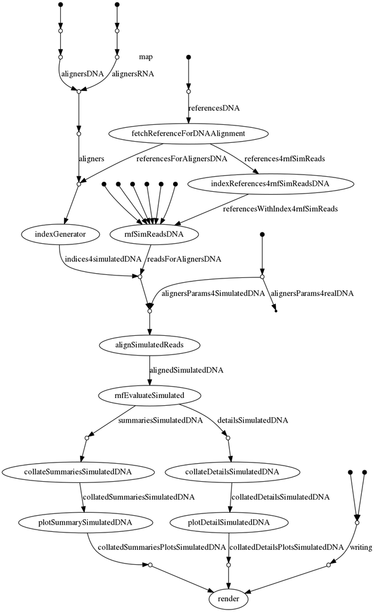

## The challenge

- Large analysis workflows are fragile ecosystems of software tools, scripts and dependencies.
- This complexity commonly makes these workflows not only irreproducible but sometimes even not re-runnable outside their original development environment.
- Even small workflows affected

[figure not shown]

https://www.nature.com/articles/d41586-019-02619-z

### Workflow systems turn raw data into scientific knowledge

- Reinventing the wheel is pointless, but for computational biologists it’s sometimes unavoidable
- Large, complex code base of
  - “Bits had been bolted on in an ad hoc fashion over seven years by at least four different developers.”
  - “heavily tied to the compute infrastructure”

### Workflow systems turn raw data into scientific knowledge

- So, do you need a workflow system?
  - Not every task requires one, and there is a learning curve.
  - Scripting usually suffices for one-off tasks and when working out the pipeline itself.
  - But The tipping point, most agree, comes when you need to run the same workflow over and over again, or if the data are likely to be published.
- Philip Ewels:
  - The languages are easy to pick up, and examples are abundant.
  - Once you’re familiar with it, you get in the habit of using it, **And then you wonder how you ever lived without it.**

https://www.nature.com/articles/d41586-019-02619-z

https://xkcd.com/242/

### Let others and your future self(!)

- reliably re-run your analyses
- trace back origins of results

### Re-running pipelines

- new data (e.g. additional samples)
- updated software
- different compute environment (cloud?)
- errors found
- new ideas
- and any combination of the above

## Push-button workflow wish-list

[figure not shown]

- version controlled
- container-backed
- seamless execution across different environments (if computationally feasible)
  - laptop/server/cluster/cloud
- sharable
  - effort required for someone else to use it

## [Nextflow](https://www.nextflow.io/)

- Reactive workflow framework
- Domain specific programming language
- Aimed at bioinformaticians familiar with programming
- Designed for seamless scalability of existing tools and scripts
  - Implicitly parallelized, asynchronous data streams
- Separation of pipeline logic from the definitions of
  - software environment (on `$PATH`, modules, binaries, conda, containers)
  - execution environment (laptop, server, cluster, cloud)

https://www.nature.com/articles/nbt.3820/

[figure not shown]

Credit: [Evan Floden](https://speakerdeck.com/skptic/nextflow-hackathon-2018-introduction-to-nextflow?slide=15)

## Practical (1)

## Nextflow building blocks

### *Processes* (1-to-many tasks)

- safe and lock-free parallelization
- executed in separate work directories
- easy clean-up, no issue of partial results following an error

### *Channels*

- facilitate data flow between processes by linking their outputs/inputs
- a suite of [operators](https://www.nextflow.io/docs/latest/operator.html) applied to channels to shape the data flow
  - filtering, transforming, forking, combining…

https://www.nature.com/articles/nbt.3820/

## Parallelisation

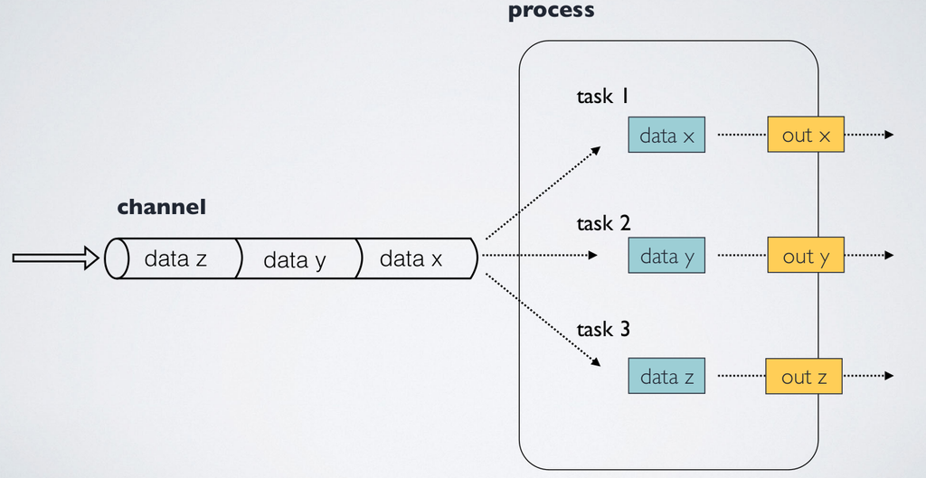

Credit: [Evan Floden](https://speakerdeck.com/skptic/nextflow-hackathon-2018-introduction-to-nextflow?slide=20)

- Independent tasks will run in parallel (Ts & Cs apply)
- Reduced overallocation of resources

## Getting started

### Install

```
curl -s https://get.nextflow.io | bash
```

### Software you want to run

- Available on PATH or under `bin/`
- via Docker
- via Singularity
- via Conda
- via Modules

## [Example workflow run](https://asciinema.org/a/233197)

Refresh page to see the embedded asciicast or go to https://asciinema.org/a/233197

## [Configuration file(s)](https://www.nextflow.io/docs/latest/config.html)

- `nextflow.config`
- `$HOME/.nextflow/config`
- But also
  - Include multiple config files via [`includeConfig`](https://www.nextflow.io/docs/latest/config.html#config-include)

  ```
  includeConfig 'conf/data.config'
  ```

  - Extend config by passing additional file at run time `-c additional.config`
  - Ignore default and use custom config file passed at run time `-C custom.config`
- [Config scopes](https://www.nextflow.io/docs/latest/config.html#config-scopes) e.g. `env`, `params`, `process`, `docker`…
- [Config profiles](https://www.nextflow.io/docs/latest/config.html#config-profiles) (!)

### Recall: separation of workflow logic from compute, software envs

- Much about software, execution environments *can* be defined in the *directive* declarations block at the top of the process body e.g.

```bash
process extract_reads {
  executor 'slurm'
  module 'samtools/1.9'
```

- Usually preferred to define these in [`nextflow.config`](https://github.com/csiro-crop-informatics/nextflow-embl-abr-webinar/blob/master/nextflow.config) *et al.*

```
params {
  outdir = "./results" //can be overwritten at run-time e.g. --outdir dirname
  infodir = "./flowinfo" //can be overwritten at run-time e.g. --infodir dirname
  take = 1 //can be overwritten at run-time e.g. --take 2 to just process first two accessions or --take all to process all
  data = './data' //input data directory

  //For read trimming
  adapters = "https://raw.githubusercontent.com/timflutre/trimmomatic/master/adapters/TruSeq3-PE.fa"
}

process {
  cache = 'lenient'
}

profiles {
  //EXECUTORS
  slurm {
    process {
      executor = 'slurm'
    }
  }
  //SOFTWARE
  conda {
    process {
      conda = "$baseDir/conf/conda.yaml"
    }
  }
  docker {
    process.container = 'rsuchecki/nextflow-embl-abr-webinar'
    docker {
      enabled = true
      fixOwnership = true
    }
  }
  singularity {
    process {
      //container = 'shub://csiro-crop-informatics/nextflow-embl-abr-webinar' //Singularity hub - ok for personal use, but we don't want to hammer them during training
      container = '/shared/.singularity/nextflow-embl-abr-webinar.simg' //local
      //scratch = true //This is a hack needed for singularity versions approx after 2.5 and before 3.1.1 as a workaround for https://github.com/sylabs/singularity/issues/1469#issuecomment-469129088
    }
    singularity {
      enabled = true
      autoMounts = true
      cacheDir = "singularity-images"  //when distibuting the pipeline probably should point under $workDir
    }
  }
  remoteContainer {
    process.container = 'rsuchecki/nextflow-embl-abr-webinar' //pulled from Docker hub - Singularity container is built from docker image so not ideal for reproducibility
  }
}

//SETUP DATA (OPTIONAL)
includeConfig 'conf/data.config'

//GENERATE REPORT https://www.nextflow.io/docs/latest/tracing.html//trace-report
report {
    enabled = true
    file = "${params.infodir}/report.html"
}

//GENERATE TIMELINE https://www.nextflow.io/docs/latest/tracing.html//timeline-report
timeline {
    enabled = true
    timeline.file = "${params.infodir}/timeline.html"
}

//GENERATE PIPELINE TRACE https://www.nextflow.io/docs/latest/tracing.html//trace-report
trace {
    enabled = true
    file = "${params.infodir}/trace.txt"
}

//GENERATE GRAPH REPRESENTATION OF THE PIPELINE FLOW
dag {
    enabled = true
    file = "${params.infodir}/flowchart.dot"
    // file = "${params.infodir}/flowchart.png" //requires graphviz for rendering
}
```

## Configuration profiles

```bash
#Local/server
nextflow run csiro-crop-informatics/nextflow-embl-abr-webinar -profile conda
nextflow run csiro-crop-informatics/nextflow-embl-abr-webinar -profile docker
nextflow run csiro-crop-informatics/nextflow-embl-abr-webinar -profile singularity

#HPC
nextflow run csiro-crop-informatics/nextflow-embl-abr-webinar -profile slurm,conda,condamodule
nextflow run csiro-crop-informatics/nextflow-embl-abr-webinar -profile slurm,singularity,singularitymodule

#Cloud
nextflow run csiro-crop-informatics/nextflow-embl-abr-webinar -profile awsbatch \
  -work-dir s3://your_s3_bucket/work --outdir s3://your_s3_bucket/results
```

## Setting up software environment(s)

- Global software env for the workflow
- Separate software envs for individual processes or subsets
- A bit of both
- Our example workflow:
  - global Conda env -> Docker -> Singularity

## Software environment (Conda)

- can be
  - used directly
  - to build a container
  - slow…

> Conda fail: the infinite “solving environment” wheel of death.  
> I just downloaded the software and built from source. It was much faster.[#conda](https://twitter.com/hashtag/conda?src=hash&ref_src=twsrc%5Etfw) [#bioconda](https://twitter.com/hashtag/bioconda?src=hash&ref_src=twsrc%5Etfw) [#wheelofdeath](https://twitter.com/hashtag/wheelofdeath?src=hash&ref_src=twsrc%5Etfw)

> — Nils Homer (@nilshomer) [February 7, 2019](https://twitter.com/nilshomer/status/1093380228833980416?ref_src=twsrc%5Etfw)
- Conda environment defined for this workflow
  - [`conf/conda.yaml`](https://raw.githubusercontent.com/csiro-crop-informatics/nextflow-embl-abr-webinar/master/conf/conda.yaml)

```
name: tutorial
channels:
 - bioconda
 - conda-forge
 - default
dependencies:
 - fastqc=0.11.8
 - multiqc=1.7
 - trimmomatic=0.36
 - pigz=2.3.4
 - bwa=0.7.17
 - samtools=1.9
 - htslib=1.9
 - unzip=6.0
 - tabix=0.2.6
 - gnu-wget=1.18
```

- Conda profile defined in [`nextflow.config`](https://github.com/csiro-crop-informatics/nextflow-embl-abr-webinar/blob/master/nextflow.config)

```
profiles {
  conda {
    process {
      conda = "$baseDir/conf/conda.yaml"
    }
  }
}
```

## Software environment (Docker)

- Container image (automated build) on Docker Hub

[figure not shown]

- Need not be conda-based
- Dockerfile

```
FROM rsuchecki/miniconda3:4.5.12

ENV LANG C.UTF-8
ENV LC_ALL C.UTF-8

LABEL maintainer="Rad Suchecki <rad.suchecki@csiro.au>"
SHELL ["/bin/bash", "-c"]

COPY conf/conda.yaml /
RUN conda env create -f /conda.yaml && conda clean -a
ENV PATH /opt/conda/envs/tutorial/bin:$PATH
```

- Docker profile defined in [`nextflow.config`](https://github.com/csiro-crop-informatics/nextflow-embl-abr-webinar/blob/master/nextflow.config)

```
  docker {
    process.container = 'rsuchecki/nextflow-embl-abr-webinar'
    docker {
      enabled = true
      fixOwnership = true
    }
  }
```

- NF pulls the container image from Docker Hub when our pipeline is run with `-profile docker` (or `-profile awsbatch`)

## Software environment (Singularity)

- Singularity *can* pull from Docker Hub and convert to its format
- Dedicated build on Singularity Hub

[figure not shown]

  - ensures the same image is used (reproducibility!)
  - Need not be Docker based
  - Build automation less flexible than on Docker Hub
  - Singularity recipe

```
Bootstrap:docker
From:rsuchecki/nextflow-embl-abr-webinar:latest
```

- Singularity profile defined in [`nextflow.config`](https://github.com/csiro-crop-informatics/nextflow-embl-abr-webinar/blob/master/nextflow.config)

```
  singularity {
    process.container = 'shub://csiro-crop-informatics/nextflow-embl-abr-webinar' //Singularity hub
    singularity {
      enabled = true
      autoMounts = true
    }
  }
```

- NF pulls the container image from Singularity Hub when our pipeline is run with `-profile singularity`

### Pipeline outputs:

- The `publishDir` directive
  - define end products of a pipeline
  - make them easily accessible

```bash
cat ../conf/publish.config
```

```
process {
  withName: multiqc_raw {
    publishDir {
      path = "${params.outdir}/qc_raw"
      mode = "${params.publishmode}"
    }
  }
  withName: multiqc_trimmed {
    publishDir {
      path = "${params.outdir}/qc_trimmed"
      mode = "${params.publishmode}"
    }
  }
  withName: bwa_mem {
    publishDir {
      path = "${params.outdir}/bwa"
      mode = "${params.publishmode}"
    }
  }
  //Currently not applied, add:
  //label 'stats'
  //at the top of a process definition to store declared outputs as follows
  withLabel: stats {
    publishDir {
      path = "${params.outdir}/stats"
      mode = "${params.publishmode}"
    }
  }
}
```

### Pipeline outputs

```bash
tree -L 2 results
```

```
results
├── bwa
│   └── ACBarrie.bam
├── downloaded
│   └── iwgsc_refseqv1.0_chr4A.fsa.zip
├── downloaded_reads
│   ├── ACBarrie_R1.fastq.gz
│   └── ACBarrie_R2.fastq.gz
├── flowinfo
│   ├── report.html
│   ├── timeline.html
│   ├── trace.txt
│   └── trace.txt.1
├── qc_raw
│   ├── multiqc_data
│   └── multiqc_report.html
└── qc_trimmed
    ├── multiqc_data
    └── multiqc_report.html

8 directories, 10 files
```

## [AWS Batch execution](https://asciinema.org/a/233421)

Refresh page to see the embedded asciicast or go to https://asciinema.org/a/233421

### Workflow introspection

- Nextflow offers detailed
  - execution reports
    - [example AWS Batch run](https://csiro-crop-informatics.github.io/nextflow-embl-abr-webinar/report.html)
  - execution timelines
    - [example AWS Batch run](https://csiro-crop-informatics.github.io/nextflow-embl-abr-webinar/timeline_aws.html)
    - [example local run](https://csiro-crop-informatics.github.io/nextflow-embl-abr-webinar/timeline.html)

### NF Resources

- https://www.nextflow.io/
- [https://github.com/nextflow-io/patterns](http://nextflow-io.github.io/patterns/)
- [Nextflow Gitter](https://gitter.im/nextflow-io/nextflow)
- https://github.com/nextflow-io/awesome-nextflow
- http://nf-co.re/ - check it out before implementing something

### Acknowledgments

- Nextflow dev team
  - Paolo Di Tommaso [@PaoloDiTommaso](https://twitter.com/paoloditommaso?lang=en)
  - Evan Floden [@EvanFloden](https://twitter.com/EvanFloden)
  - *et al.*
- University of Adelaide
  - Nathan Watson-Haigh [@watsonhaigh](https://twitter.com/watsonhaigh)
- Nextflow community on [Gitter](https://gitter.im/nextflow-io/nextflow)
- CSIRO
  - Alex Whan [@alexwhan](https://twitter.com/alexwhan)
  - Jen Taylor [@JenMTaylor](https://twitter.com/JenMTaylor)
  - Ondrej Hlinka (HPC)
  - *et al.*

[figure not shown]